# Explained variation and human importance

## Response to the reviewer

We thank the reviewer for asking how much variation the human-impact and climate predictors explain, and whether model fit covaries with the estimated importance of human impact.

We added a direct commonality decomposition for every available H1 model. Unique human, unique climate, shared, and total adjusted R² fractions come from `Var.part`. Hierarchical individual importance remains a separate quantity from `Hier.part`. This follows the [rdacca.hp contract](https://search.r-project.org/CRAN/refmans/rdacca.hp/html/rdacca.hp.html) and [Lai et al. (2022)](https://doi.org/10.1111/2041-210X.13800).

For each model, total adjusted R² equals unique human plus unique climate plus shared explained variation. Adding unexplained variation reconstructs one. Signed adjusted fractions are primary; the complete bounded decomposition sensitivity remains available in the source tables. These are joint multivariate models of ten pollen-derived properties, not ten independent fits.

Across the four H1 analyses, 1565 of 2679 model records had complete decompositions. No available model exceeded the 0.001 accounting tolerance. For spatial SPD, 1156 decompositions had a median adjusted R² of 0.355 (interquartile range 0.231 to 0.482). We show record-level distributions rather than sums because sums scale directly with the number of models in each group.

Table 1: Availability, accounting, and signed-component audit for H1.

| Analysis | Models | Available | Invalid | Neg. human | Neg. climate | Neg. shared |
| --- | --- | --- | --- | --- | --- | --- |
| spatial_events | 1262 | 263 | 0 | 56 | 31 | 74 |
| spatial_spd | 1262 | 1156 | 0 | 428 | 108 | 347 |
| temporal_events | 85 | 76 | 0 | 13 | 0 | 14 |
| temporal_spd | 70 | 70 | 0 | 13 | 1 | 22 |

## Three independent figure products

The first figure shows the distribution of signed adjusted R² values within each continent and climate-zone combination. Points are individual spatial SPD models, boxes show medians and interquartile ranges, and violins show distribution shape when at least three varying values are available. Finite negative adjusted R² values are retained.

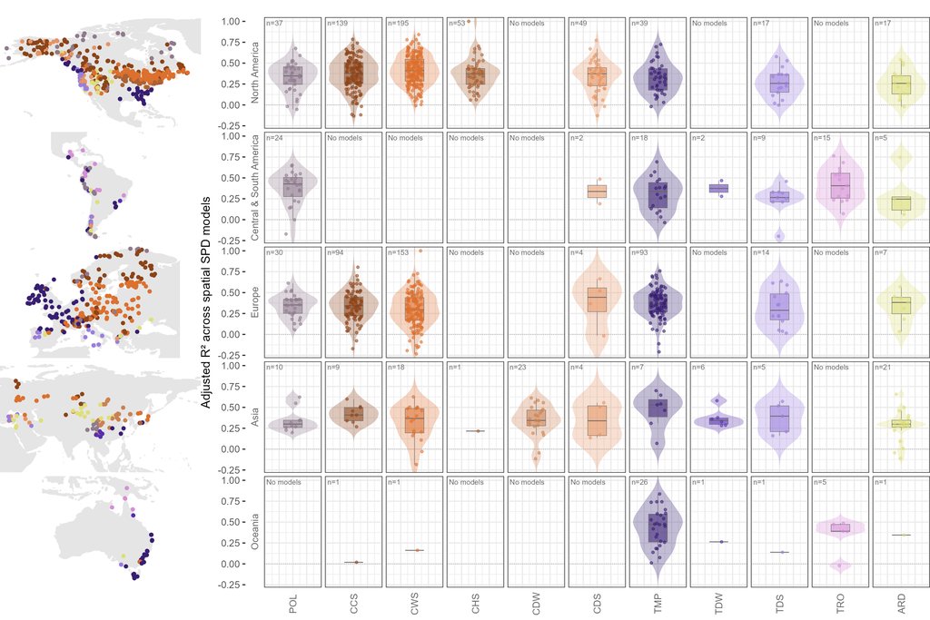

Figure 1: Adjusted R-squared distributions by continent and climate zone. Points are individual models; boxes show medians and interquartile ranges.

The correlation figures use signed relative human importance only; no zero-truncated importance figure is shown. Across 1118 eligible spatial SPD models, Spearman ρ = 0.022 and Pearson r = -0.021.

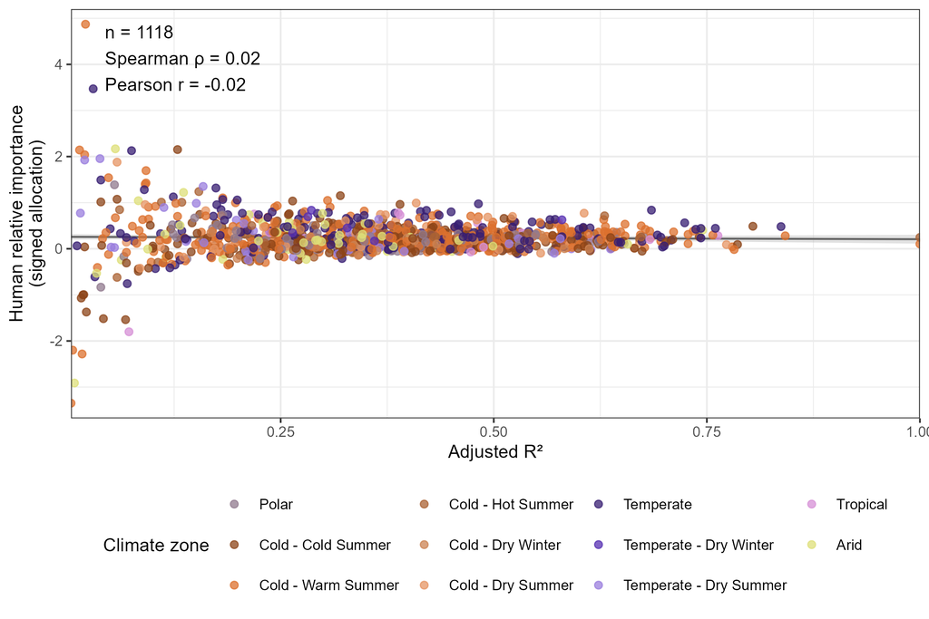

Figure 2: Adjusted R-squared and signed human relative importance across eligible spatial SPD models.

The grid uses five continent rows and eleven climate-zone columns. Populated panels report n and Spearman ρ. Statistics and trend lines require at least three observations and non-zero variation. Absent combinations remain explicit empty cells.

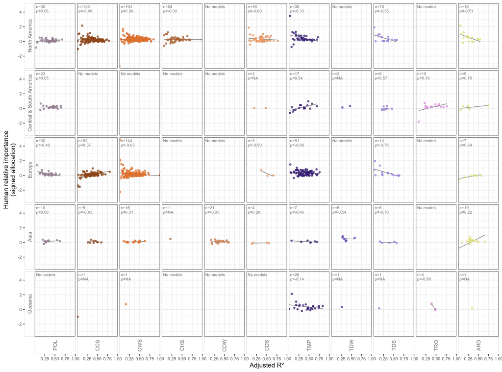

Figure 3: Adjusted R-squared and signed human relative importance by continent and climate zone.

All model values, distribution summaries, audits, and signed correlation statistics are exported under `Outputs/Tables/HVarPart`. The validation script independently reconstructs every distribution summary, model count, Spearman coefficient, and Pearson coefficient.